# Responsibility of each member:

Guanxu Su: Step3-model building, step4-diagnostic and the corresponding code, image, presentation.

Chenlai Shi: Step1-introduction, step2:data cleaning and the corresponding code, image, presentation.

Jing Tao: Step3-k-fold mse, step5-conclusion-Strength and weakness and the corresponding code, image, presentation.

# Step 1: Introduction

Wikipedia's definition of body fat percentage is the total mass of fat divided by total body mass, times 100. It is considered as an important measure of fitness level based on various theoretical approaches about the relationships between body fat percentage, health, athletic capacity, etc. There exist different measurement techniques, such as underwater weighing, whole-body air displacement plethysmography, body average density measurement and so on. However, none of them can achieve simplicity, robustness and precision simultaneously, which motivates our project on developing a new method to estimate percentage of body fat of men, that is easy-to-use, robust, scalable and accurate.

# Step 2: Data Cleaning

Our survey dataset consists of 252 men with measurements of percent body fat from Siri's (1956) equation, density determined from underwater weighing, age, weight, height, adioposity (bmi), neck circumference, chest circumference, abdomen 2 circumference, hip circumference, thigh circumference, knee circumference, ankle circumference, biceps (extended) circumference, forearm circumference, wrist circumference. We convert all heights into cm, weights into kg. And the data looks like this:

```r
remove(list = ls())
bodyfat <- read.csv("BodyFat.csv")
#Units change
bodyfat$WEIGHT <- 0.4536*bodyfat$WEIGHT
bodyfat$HEIGHT <- 2.54*bodyfat$HEIGHT
head(bodyfat,n=5)
```

| IDNO | BODYFAT | DENSITY | AGE | WEIGHT | HEIGHT | ADIPOSITY | NECK | CHEST | ABDOMEN | HIP | THIGH | KNEE | ANKLE | BICEPS | FOREARM | WRIST |
| --- | --- | --- | --- | --- | --- | --- | --- | --- | --- | --- | --- | --- | --- | --- | --- | --- |
| 1 | 12.6 | 1.0708 | 23 | 69.9678 | 172.085 | 23.7 | 36.2 | 93.1 | 85.2 | 94.5 | 59.0 | 37.3 | 21.9 | 32.0 | 27.4 | 17.1 |
| 2 | 6.9 | 1.0853 | 22 | 78.5862 | 183.515 | 23.4 | 38.5 | 93.6 | 83.0 | 98.7 | 58.7 | 37.3 | 23.4 | 30.5 | 28.9 | 18.2 |
| 3 | 24.6 | 1.0414 | 22 | 69.8544 | 168.275 | 24.7 | 34.0 | 95.8 | 87.9 | 99.2 | 59.6 | 38.9 | 24.0 | 28.8 | 25.2 | 16.6 |
| 4 | 10.9 | 1.0751 | 26 | 83.8026 | 183.515 | 24.9 | 37.4 | 101.8 | 86.4 | 101.2 | 60.1 | 37.3 | 22.8 | 32.4 | 29.4 | 18.2 |
| 5 | 27.8 | 1.0340 | 24 | 83.5758 | 180.975 | 25.6 | 34.4 | 97.3 | 100.0 | 101.9 | 63.2 | 42.2 | 24.0 | 32.2 | 27.7 | 17.7 |

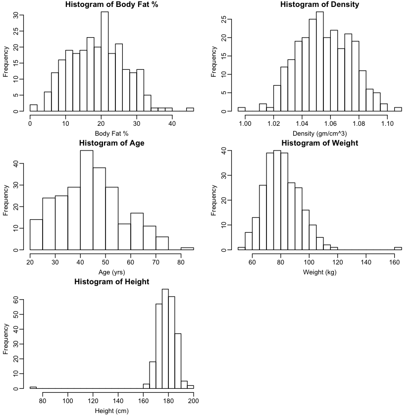

```r
#####Data Cleaning####
par(mfrow=c(3,2))
par(mgp=c(1.8,.5,0), mar=c(3,3,1,1)) #"Beautifies" plots when creating multiple figures. Google this for more info.
hist(bodyfat$BODYFAT,breaks=20,
     main="Histogram of Body Fat %",xlab="Body Fat %")
hist(bodyfat$DENSITY,breaks=20,
     main="Histogram of Density",xlab="Density (gm/cm^3)")
hist(bodyfat$AGE,breaks=20,
     main="Histogram of Age",xlab="Age (yrs)")
hist(bodyfat$WEIGHT,breaks=30,
     main="Histogram of Weight",xlab="Weight (kg)")
hist(bodyfat$HEIGHT,breaks=30,
     main="Histogram of Height",xlab="Height (cm)")
```

```r
bodyfat[bodyfat$BODYFAT>=45|bodyfat$BODYFAT<3,]
```

|  | IDNO | BODYFAT | DENSITY | AGE | WEIGHT | HEIGHT | ADIPOSITY | NECK | CHEST | ABDOMEN | HIP | THIGH | KNEE | ANKLE | BICEPS | FOREARM | WRIST |
| --- | --- | --- | --- | --- | --- | --- | --- | --- | --- | --- | --- | --- | --- | --- | --- | --- | --- |
| 172 | 172 | 1.9 | 1.0983 | 35 | 57.0402 | 166.37 | 20.6 | 34.0 | 90.8 | 75.0 | 89.2 | 50.0 | 34.8 | 22.0 | 24.8 | 25.9 | 16.9 |
| 182 | 182 | 0.0 | 1.1089 | 40 | 53.7516 | 172.72 | 18.1 | 33.8 | 79.3 | 69.4 | 85.0 | 47.2 | 33.5 | 20.2 | 27.7 | 24.6 | 16.5 |
| 216 | 216 | 45.1 | 0.9950 | 51 | 99.3384 | 162.56 | 37.6 | 41.2 | 119.8 | 122.1 | 112.8 | 62.5 | 36.9 | 23.6 | 34.7 | 29.1 | 18.4 |

```r
bodyfat[bodyfat$DENSITY<1|bodyfat$DENSITY>1.1,]
```

|  | IDNO | BODYFAT | DENSITY | AGE | WEIGHT | HEIGHT | ADIPOSITY | NECK | CHEST | ABDOMEN | HIP | THIGH | KNEE | ANKLE | BICEPS | FOREARM | WRIST |
| --- | --- | --- | --- | --- | --- | --- | --- | --- | --- | --- | --- | --- | --- | --- | --- | --- | --- |
| 182 | 182 | 0.0 | 1.1089 | 40 | 53.7516 | 172.72 | 18.1 | 33.8 | 79.3 | 69.4 | 85.0 | 47.2 | 33.5 | 20.2 | 27.7 | 24.6 | 16.5 |
| 216 | 216 | 45.1 | 0.9950 | 51 | 99.3384 | 162.56 | 37.6 | 41.2 | 119.8 | 122.1 | 112.8 | 62.5 | 36.9 | 23.6 | 34.7 | 29.1 | 18.4 |

```r
bodyfat[bodyfat$AGE>80,]
```

|  | IDNO | BODYFAT | DENSITY | AGE | WEIGHT | HEIGHT | ADIPOSITY | NECK | CHEST | ABDOMEN | HIP | THIGH | KNEE | ANKLE | BICEPS | FOREARM | WRIST |
| --- | --- | --- | --- | --- | --- | --- | --- | --- | --- | --- | --- | --- | --- | --- | --- | --- | --- |
| 79 | 79 | 21.1 | 1.0498 | 81 | 73.143 | 178.435 | 23 | 37.8 | 96.4 | 95.4 | 99.3 | 53.5 | 37.5 | 21.5 | 31.4 | 26.8 | 18.3 |

```r
bodyfat[bodyfat$WEIGHT>150,]
```

|  | IDNO | BODYFAT | DENSITY | AGE | WEIGHT | HEIGHT | ADIPOSITY | NECK | CHEST | ABDOMEN | HIP | THIGH | KNEE | ANKLE | BICEPS | FOREARM | WRIST |
| --- | --- | --- | --- | --- | --- | --- | --- | --- | --- | --- | --- | --- | --- | --- | --- | --- | --- |
| 39 | 39 | 33.8 | 1.0202 | 46 | 164.7248 | 183.515 | 48.9 | 51.2 | 136.2 | 148.1 | 147.7 | 87.3 | 49.1 | 29.6 | 45 | 29 | 21.4 |

```r
bodyfat[bodyfat$HEIGHT<140,]
```

|  | IDNO | BODYFAT | DENSITY | AGE | WEIGHT | HEIGHT | ADIPOSITY | NECK | CHEST | ABDOMEN | HIP | THIGH | KNEE | ANKLE | BICEPS | FOREARM | WRIST |
| --- | --- | --- | --- | --- | --- | --- | --- | --- | --- | --- | --- | --- | --- | --- | --- | --- | --- |
| 42 | 42 | 31.7 | 1.025 | 44 | 92.988 | 74.93 | 29.9 | 36.6 | 106 | 104.3 | 115.5 | 70.6 | 42.5 | 23.7 | 33.6 | 28.7 | 17.4 |

By observing histogram of key variables, we focused on outliers, including bodyfat>=45 and <3, density<1 and >1.1, age>80, weight>150, height<140. We consider it very unlikely for a normal man to have body fat percentage <3% but ID 216 is likely to have high body fat percentage given his large weight relative to height, large abdomen 2 circumference and hip circumference. So we remove ID 172 and 182. We do not identify any abnormality for men with body density<1 and >1.1, age>80. For ID 39, even though his weight is >150, we cannot remove this observation for his large abdomen 2 circumference and hip circumference. For ID 42, height is too small for a normal man of 44 years old and we remove this observation.

According to Siri's(1956) equation", Percentage of Body Fat (i.e. 100*proportion of fat tissue) = 495/body density - 450. Although the measure of data may be different, body fat percentage is also supposed to lie on a straight line with respect to body density in our data. So we remove abnormal points from plot of body fat percentage against body density.

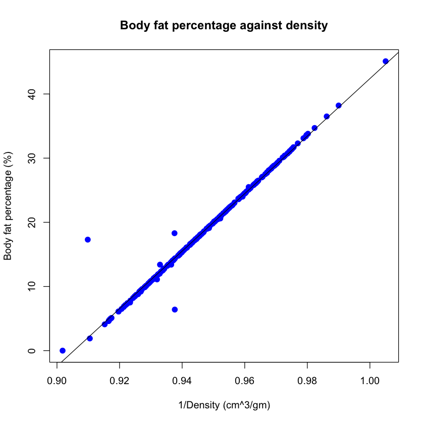

```r
siri_data <- data.frame(ID=bodyfat$IDNO,BODYFAT=bodyfat$BODYFAT,DENSITY_INVERSE=1/bodyfat$DENSITY)
plot(BODYFAT~DENSITY_INVERSE,data=siri_data, pch = 16, cex = 1.3, col = "blue", main = "Body fat percentage against density", xlab = "1/Density (cm^3/gm)", ylab = "Body fat percentage (%)")
abline(lm(BODYFAT~DENSITY_INVERSE,data=siri_data))
```

```r
siri.lm = lm(BODYFAT~DENSITY_INVERSE,data=siri_data)
siri.res = resid(siri.lm)
bodyfat[abs(siri.res)>1.5,]
```

|  | IDNO | BODYFAT | DENSITY | AGE | WEIGHT | HEIGHT | ADIPOSITY | NECK | CHEST | ABDOMEN | HIP | THIGH | KNEE | ANKLE | BICEPS | FOREARM | WRIST |
| --- | --- | --- | --- | --- | --- | --- | --- | --- | --- | --- | --- | --- | --- | --- | --- | --- | --- |
| 48 | 48 | 6.4 | 1.0665 | 39 | 67.3596 | 180.975 | 20.6 | 34.6 | 89.8 | 79.5 | 92.7 | 52.7 | 37.5 | 21.9 | 28.8 | 26.8 | 17.9 |
| 76 | 76 | 18.3 | 1.0666 | 61 | 67.2462 | 171.450 | 22.9 | 36.0 | 91.6 | 81.8 | 94.8 | 54.5 | 37.0 | 21.4 | 29.3 | 27.0 | 18.3 |
| 96 | 96 | 17.3 | 1.0991 | 53 | 101.8332 | 197.485 | 26.1 | 41.1 | 113.2 | 99.2 | 107.5 | 61.7 | 42.3 | 23.2 | 32.9 | 30.8 | 20.4 |
| 182 | 182 | 0.0 | 1.1089 | 40 | 53.7516 | 172.720 | 18.1 | 33.8 | 79.3 | 69.4 | 85.0 | 47.2 | 33.5 | 20.2 | 27.7 | 24.6 | 16.5 |

We further remove any observation,i.e. ID 48, 76 and 96, with relatively large residual along the fitted line because those men are abnormal according to Siri's(1956). They are unable to be explained by our SLR model and would influence the model fitting.

```r
bodyfat<-bodyfat[-c(172,182,42,48,76,96),]
dim(bodyfat)
```

1. 246

2. 17

# Step 3: Statistical Modeling and Analysis

Since there is strong linear relationship between $Bodyfat$ and $\frac{1}{Density}$, we decide to first try to predict $Density$, and then find the corresponding $Bodyfat$.

Note that $\frac{1}{Density}=\frac{Volume}{Weight}$, where $Volume$ has closer relationship with our measurable quantitives such as $Weight$, $Hip$, $Wrist$, etc. Actually, we will show that the SLR has a very high $R^2$ which is above 0.997.

Hence, we gonna first fit a SLR for $Volume$ which can be calculated by $\frac{Weight}{Density}$. Then we get our $\frac{1}{Density}$ given by $\frac{Volume}{Weight}$. Finally, we get the predicted $Bodyfat$. The procedure is like the following workflow:

$$\text{Measurable variables}\Rightarrow\text{Volume}\Rightarrow\frac{1}{\text{Density}}\Rightarrow\text{Bodyfat}$$

The first step of this part is data manipulation. We think that the variables with unit $cm$ should take the third power so that their unit becomes $cm^3$. We believe that the power transformation would help to satisfy the linearity assumption.

```r
#### Data transformation####
bodyfat$NECK3 <- bodyfat$ADIPOSITY^3
bodyfat$CHEST3 <- bodyfat$CHEST^3
bodyfat$ABDOMEN3 <- bodyfat$ABDOMEN^3
bodyfat$HIP3 <- bodyfat$HIP^3
bodyfat$THIGH3 <- bodyfat$THIGH^3
bodyfat$KNEE3 <- bodyfat$KNEE^3
bodyfat$ANKLE3 <- bodyfat$ANKLE^3
bodyfat$BICEPS3 <- bodyfat$BICEPS^3
bodyfat$FOREARM3 <- bodyfat$FOREARM^3
bodyfat$WRIST3 <- bodyfat$WRIST^3
```

The second step is to do variable selection. To get less variables and make our rule-of-thumb as simple as possible, we choose BIC as our criterion in the stepwise variable selection procedure.

```r
#### Variable selection ####
bodyfat$volume <- bodyfat$WEIGHT/bodyfat$DENSITY
volume_data <- bodyfat
volume_data$IDNO<-NULL;volume_data$BODYFAT<-NULL;volume_data$DENSITY<-NULL
step_model <- step(lm(volume~.,data=volume_data),direction = "both",k=log(nrow(volume_data)),trace = 0)
summary(step_model)
```

```
Call:
lm(formula = volume ~ WEIGHT + HIP + WRIST + ABDOMEN3 + HIP3,
    data = volume_data)

Residuals:
     Min       1Q   Median       3Q      Max
-1.87466 -0.45588 -0.02233  0.49925  1.82356

Coefficients:
              Estimate Std. Error t value Pr(>|t|)
(Intercept) -1.206e+01  2.784e+00  -4.331 2.18e-05 ***
WEIGHT       9.195e-01  1.229e-02  74.811  < 2e-16 ***
HIP          2.173e-01  3.870e-02   5.615 5.43e-08 ***
WRIST       -2.500e-01  7.190e-02  -3.477 0.000601 ***
ABDOMEN3     6.105e-06  3.337e-07  18.295  < 2e-16 ***
HIP3        -7.604e-06  1.026e-06  -7.408 2.17e-12 ***
---
Signif. codes:  0 ‘***’ 0.001 ‘**’ 0.01 ‘*’ 0.05 ‘.’ 0.1 ‘ ’ 1

Residual standard error: 0.6909 on 240 degrees of freedom
Multiple R-squared:  0.9974,	Adjusted R-squared:  0.9973
F-statistic: 1.841e+04 on 5 and 240 DF,  p-value: < 2.2e-16
```

Now we have the model of the first part, that is

$$\text{Volume}_i=\beta_0+\beta_1\text{Weight}_i+\beta_2\text{Hip}_i+\beta_3\text{Wrist}_i+\beta_4\text{Abdomen}_i^3+\beta_5\text{Hip}_i^3+\varepsilon_i, \quad \varepsilon_i\sim N(0,\sigma^2)$$

For example, a man who is 70kg, hip circumference equals to 95cm, wrist circumference equals to 17cm, abdomen 2 circumference equals to 85cm would have volume around 65.93$dm^3$. There is a 95% probability that his volume is between 64.55$dm^3$ and 67.31$dm^3$.

```r
predict(step_model,newdata=data.frame(WEIGHT=70,HIP=95,WRIST=17,ABDOMEN3=85^3,HIP3=95^3),interval="predict")
```

|  | fit | lwr | upr |
| --- | --- | --- | --- |
| 1 | 65.92771 | 64.55892 | 67.29651 |

**Observation 2**: Men gain 0.920$dm^3$ on average for every extra kilogram weight with other variables being the same.

**Observation 3**: Men gain 0.217$dm^3$ on average for every extra centimetre hip circumference with other variables being the same.

**Observation 4**: Men loss 0.250$dm^3$ on average for every extra centimetre wrist circumference with other variables being the same.

**Observation 5**: Men gain $6.105\times10^{-6}dm^3$ on average for every extra $cm^3$ abdomen 2 $\text{circumference}^3$ with other variables being the same.

**Observation 6**: Men loss $7.604\times10^{-6}dm^3$ on average for every extra $cm^3$ $\text{hip}^3$ with other variables being the same.

To test whether each variable has significant influence on volume, the null hypothesis for each $\beta_i$ should be $H_0:\beta_i=0$, and the alternative is $H_1:\beta_i\neq0$. The associated p-value for the 6 parameters are all less than 0.05. Hence, reject each $H_0$ with at least 95% confidence. The 95% confidence interval for $\beta_i,i=1,2,...,5$ are, respectively, (0.895,0.944), (0.141,0.293), (-0.392,-0.108), (5.45$\times10^{-6}$,6.76$\times10^{-6}$), (-9.63$\times10^{-6}$,-5.58$\times10^{-6}$)

```r
confint(step_model)
```

|  | 2.5 % | 97.5 % |
| --- | --- | --- |
| (Intercept) | -1.754312e+01 | -6.574430e+00 |
| WEIGHT | 8.953205e-01 | 9.437463e-01 |
| HIP | 1.410320e-01 | 2.934832e-01 |
| WRIST | -3.916550e-01 | -1.083898e-01 |
| ABDOMEN3 | 5.447837e-06 | 6.762606e-06 |
| HIP3 | -9.625720e-06 | -5.581878e-06 |

Next, we need to fit the SLR between $Bodyfat$ and $\frac{1}{Density}$:

$$ \text{Bodyfat}_i = \beta_0 + \beta_1\frac{1}{\text{Density}}_{i} + \epsilon_i, \quad{} \epsilon_i \sim N(0,\sigma^2) $$

```r
bodyfat_density <- data.frame(BODYFAT=bodyfat$BODYFAT,DENSITY_INVERSE=1/bodyfat$DENSITY)
density_model <- lm(BODYFAT~DENSITY_INVERSE,bodyfat_density)
summary(density_model)
```

```
Call:
lm(formula = BODYFAT ~ DENSITY_INVERSE, data = bodyfat_density)

Residuals:
     Min       1Q   Median       3Q      Max
-0.61113 -0.02322  0.00043  0.02829  1.25177

Coefficients:
                 Estimate Std. Error t value Pr(>|t|)
(Intercept)     -414.2239     0.3960   -1046   <2e-16 ***
DENSITY_INVERSE  457.0283     0.4176    1094   <2e-16 ***
---
Signif. codes:  0 ‘***’ 0.001 ‘**’ 0.01 ‘*’ 0.05 ‘.’ 0.1 ‘ ’ 1

Residual standard error: 0.1085 on 244 degrees of freedom
Multiple R-squared:  0.9998,	Adjusted R-squared:  0.9998
F-statistic: 1.198e+06 on 1 and 244 DF,  p-value: < 2.2e-16
```

Now we have the model of the second part, that is

$$\text{Bodyfat}=-414+\frac{457}{\text{Density}}$$

For example, for a male with body density equals to 1.07$gm/cm^3$, his predicted bodyfat percentage would be around 12.90%. There is a 95% probability that his body fat is between 12.69% and 13.12%.

```r
predict(density_model,newdata=data.frame(DENSITY_INVERSE=1/1.07),interval="predict")
```

|  | fit | lwr | upr |
| --- | --- | --- | --- |
| 1 | 12.90534 | 12.69092 | 13.11976 |

**Observation 2**: Men gain 457% of bodyfat% on average for every extra unit $\frac{1}{Density}$.

We can almost surely declare that there is linear relationship between $\frac{1}{Density}$ and $Bodyfat$.

Hence, the final model would be:

$$\text{Bodyfat}=-414+(-5511+420\text{Weight}+99\text{Hip}-114\text{Wrist}+2790(\text{Abdomen}^3/10^6)-3475(\text{Hip}^3/10^6))/\text{Weight}$$

Back to the example in the SRL for volume. If we consider the relationship between $\frac{1}{Density}$ and $Bodyfat$ contains no variance. Then for a man who is 70kg, hip circumference equals to 95cm, wrist circumference equals to 17cm, abdomen 2 circumference equals to 85cm would have volume around 65.93$dm^3$, there is a 95% probability that his volume is between 64.55$dm^3$ and 67.31$dm^3$. His $\frac{1}{Density}=\frac{Volume}{Weight}$ should be around 0.942 and has 95% probability to fall in (0.922$cm^3/gm$,0.961$cm^3/gm$). The 95% confidence interval for his bodyfat% would be (7.48,25.35), around 16.41.

```r
predict(step_model,newdata=data.frame(WEIGHT=70,HIP=95,WRIST=17,ABDOMEN3=85^3,HIP3=95^3),interval="predict")/70*457-414
```

|  | fit | lwr | upr |
| --- | --- | --- | --- |
| 1 | 16.41379 | 7.477499 | 25.35007 |

To check whether the model is doing the right thing with no over fitting, we decide to make K-fold cross validition.

Firstly, fit the model between bodyfat and density. Secondly, fit the model between volume and the measuable quantitives. In addition,predict the volume of testdata. At last, calculate predicted density values and then use them to predict bodyfat.

```r
predict_bodyfat <- function(traindata,testdata){
  bodyfat_density_data_train <- data.frame(BODYFAT=traindata$BODYFAT,DENSITY_INVERSE=1/traindata$DENSITY)
  bodyfat_density_model <- lm(BODYFAT~DENSITY_INVERSE,bodyfat_density_data_train)
  volume_data_train <- traindata
  volume_data_train$volume <- volume_data_train$WEIGHT/volume_data_train$DENSITY
  volume_data_train$IDNO <- NULL;volume_data_train$BODYFAT <- NULL;volume_data_train$DENSITY <- NULL
  volume_model <- lm(volume~WEIGHT+HIP+WRIST+ABDOMEN3+HIP3,volume_data_train)
  volume_data_test <- testdata
  predicted_volume <- predict(volume_model,volume_data_test)
  bodyfat_density_data_test <- data.frame(BODYFAT=testdata$BODYFAT,DENSITY_INVERSE=predicted_volume/testdata$WEIGHT)
  predicted_bodyfat <- predict(bodyfat_density_model,bodyfat_density_data_test)
  return(predicted_bodyfat)
}
```

The K-fold cross validition gives MSE about 14.

```r
set.seed(2018)
MSE <- c()
for(i in 1:10){
  test_index <- sample(1:nrow(bodyfat),floor(nrow(bodyfat)/10))
  testdata <- bodyfat[test_index,];traindata <- bodyfat[-test_index,]
  predicted.values <- predict_bodyfat(traindata,testdata)
  MSE <- c(MSE,sum((predicted.values-testdata$BODYFAT)^2)/floor(nrow(bodyfat)/10))
}
mean(MSE)
```

14.0108066235168

If weight is measured by kg, all the lengths are measured in dm, then the equaltion can be approximately expressed by:

$$\text{Bodyfat}=(-5500+6\text{Weight}+1000\text{Hip}-1000\text{Wrist}+3\text{Abdomen}^3-3.5\text{Hip}^3)/\text{Weight}$$

# Step 4: Diagnostics

This part mainly check whether the requirements for SLR of the volume model are satisfied. There are four assumptions to check:

**Linearity**: Bodyfat % has linear relationship with those explanatory variables.

**Homoskedastic**: The variance on the error terms is assumed to be constant.

**Normality**: The error terms are indipendently normal distributed with mean equals to 0.

**Additive**: The explanatory variables are additive, meaning that they are independent with each other and do not have interaction effect.

Meanwhile, this part would detect outliers and influencial points.

### First

To check **Linearity** and **Homoskedastic**, we gonna look at the residual plot:

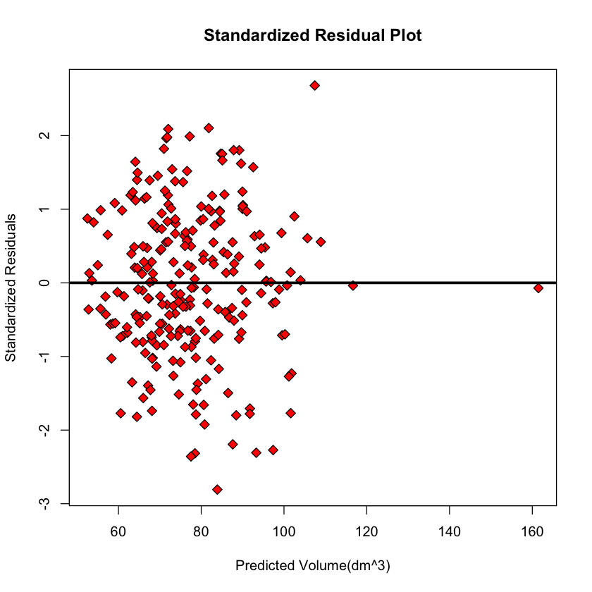

```r
plot(predict(step_model),rstandard(step_model),pch=23,bg="red",cex=1.2,
    xlab="Predicted Volume(dm^3)", ylab="Standardized Residuals",main="Standardized Residual Plot")
abline(a=0,b=0,col="black",lwd=3)
```

The standard errors are symmetrically distributed around 0. There is no obvious heteroscedasticity pattern. There is an outlier, observation No.39, with predicted volume over 160. This man has body volume 161$dm^3$. This obsercation has a extremely high Pii, which means its X data is far away from others. However, the observation does not has a high cook's distance. Hence, the observation will not be excluded.

There is also a data point which has a very high cook's distance. The observation number is 250. This men looks normal and the Pii is not high. Hence, the observation will not be excluded.

Overall, the **Linearity** and **Homoskedastic** assumptions hold.

```r
bodyfat[predict(step_model)>160,c(1,ncol(bodyfat),2:17)]
```

|  | IDNO | volume | BODYFAT | DENSITY | AGE | WEIGHT | HEIGHT | ADIPOSITY | NECK | CHEST | ABDOMEN | HIP | THIGH | KNEE | ANKLE | BICEPS | FOREARM | WRIST |
| --- | --- | --- | --- | --- | --- | --- | --- | --- | --- | --- | --- | --- | --- | --- | --- | --- | --- | --- |
| 39 | 39 | 161.4633 | 33.8 | 1.0202 | 46 | 164.7248 | 183.515 | 48.9 | 51.2 | 136.2 | 148.1 | 147.7 | 87.3 | 49.1 | 29.6 | 45 | 29 | 21.4 |

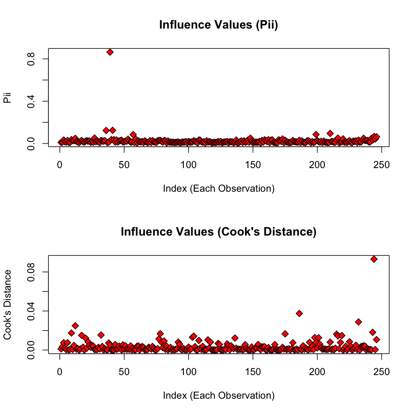

```r
pii = hatvalues(step_model)
cooki = cooks.distance(step_model)
par(mfrow = c(2,1))
n = dim(bodyfat)[1]
plot(1:n,pii,type="p",pch=23,bg="red",cex=1.2,
     xlab="Index (Each Observation)",ylab="Pii",main="Influence Values (Pii)")
plot(1:n,cooki,type="p",pch=23,bg="red",cex=1.2,
     xlab="Index (Each Observation)",ylab="Cook's Distance",main="Influence Values (Cook's Distance)")
```

```r
pii[39]
```

**39:** 0.863773973234506

```r
bodyfat[cooki>0.08,c(1,ncol(bodyfat),2:17)]
```

|  | IDNO | volume | BODYFAT | DENSITY | AGE | WEIGHT | HEIGHT | ADIPOSITY | NECK | CHEST | ABDOMEN | HIP | THIGH | KNEE | ANKLE | BICEPS | FOREARM | WRIST |
| --- | --- | --- | --- | --- | --- | --- | --- | --- | --- | --- | --- | --- | --- | --- | --- | --- | --- | --- |
| 250 | 250 | 82.01956 | 28.3 | 1.0328 | 72 | 84.7098 | 167.64 | 30.2 | 38.9 | 111.1 | 111.5 | 101.7 | 60.3 | 37.3 | 21.5 | 31.3 | 27.2 | 18 |

### Second

To check **normality**, we need to look at QQ plot. According to the plot, normality assumption holds.

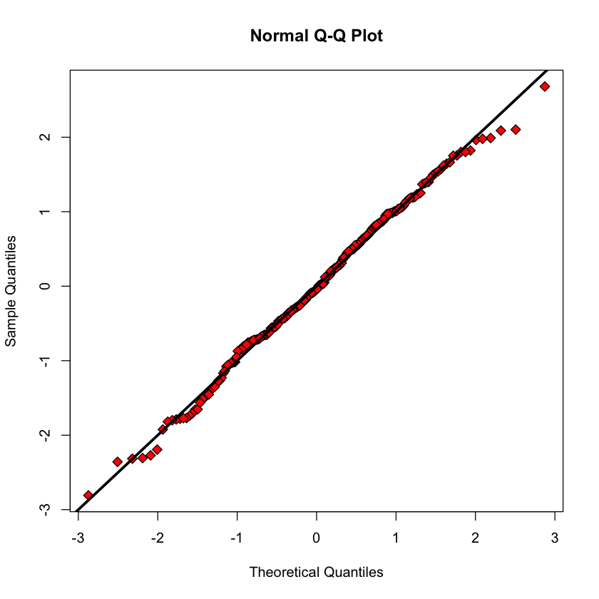

```r
qqnorm(rstandard(step_model),pch=23,bg="red",cex=1.2)
abline(a=0,b=1,col="black",lwd=3)
```

### Third

To further check **additive** and **linearity** assumption, we need to look at the Scatterplot of each variable verses the standard residual and volume.

All the variables have linear relationship with volume and are independent from residual. There exists multi-colinearity. Overall, the assumptions holds.

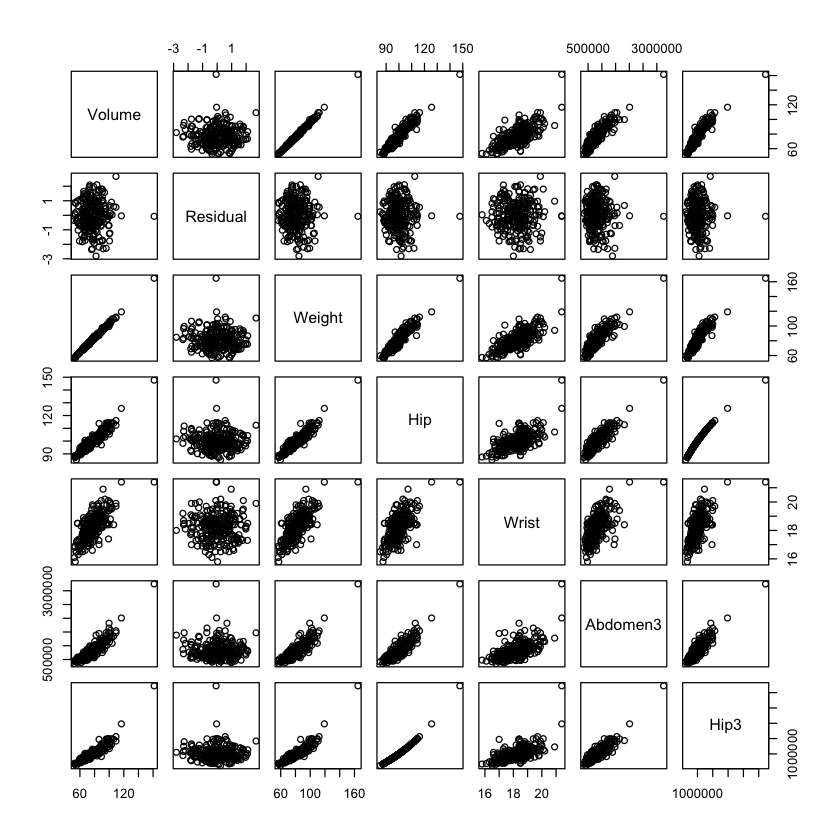

```r
additive <- data.frame(Volume=bodyfat$volume,Residual=rstandard(step_model),Weight=bodyfat$WEIGHT,Hip=bodyfat$HIP,
                      Wrist=bodyfat$WRIST,Abdomen3=bodyfat$ABDOMEN3,Hip3=bodyfat$HIP3)
pairs(additive)
```

# Step 5: Conclusion

Our Proposed Model to predict bodyfat %:

$$\text{Bodyfat}=(-5500+6\text{Weight}+1000\text{Hip}-1000\text{Wrist}+3\text{Abdomen}^3-3.5\text{Hip}^3)/\text{Weight}$$

**Rule-of-thumb**: 6 times weight(kg) plus 1000 times hip circumference(dm) minus 1000 times wrist(dm) plus 3 times abdomen 2 circumference(dm) cube minus 3.5 times hip circumference(dm) cube minus 5500 over weight(kg).

**Example Usage**: For example, for a male of weight 70 kg, hip circumference 10 dm, abdomen 9 dm, wrist 1.7 dm, with the proposed rule-of-thumb, the estimated body fat is about 27%.

**Strengths and Weakness of Model**:

1. Linearity: All the exlainary varaibles have strong linear relationship with the response varaibles in both two models.
2. Additivity: In the volume model, most variables can be added to each other.
3. Constant effects: since we don't split the whole dataset into different groups, our model may not be very precise for specific groups.
4. Fixed X: This seems reasonable for this data.
5. Normally distributed errors: after our data cleaning procedure, the QQ plot of the model looks perfect.
6. Constant variance: satisfied by looking at the residual plot.
7. The prediction of each model of the two steps are both very precise.
8. The final model is complicated in calculation.

Overall, our model provides precise prediction of bodyfat % based on weight, hip circumference, wrist circumference and abdomen circumference although it is a little complicated.